# Regression

Anna Yeaton

Fall 2019

# Lab Section

In this lab, we will go over regression. We will be using the caret package in R. https://topepo.github.io/caret/train-models-by-tag.html

# Perfomance Metrics

## Residual

Deviation of the observed value to the estimated value (sample mean)
$$residual=y_i - \hat{y_i}$$
where $\hat{y_i}$ is the estimated value

## Mean Squared Error (MSE)

$$MSE=\frac{1}{n}\sum_{i=1}^{n}(y_i - \hat{y_i})^2$$

## Root Mean Squared Error (RMSE)

Same units as original data.

$$RMSE=\sqrt{MSE}$$

## L2 regularization : Ridge regression. Regularize by adding the sum of the coefficients, squared, to the function.

$$Ridge Regression=\sum_{i=1}^{n}(y_i - w_0 - \sum_{j=1}^{p}w_jx_{ij})^2 + \lambda\sum_{j=1}^p(w_j)^2$$

## L1 regularization : Lasso Regression. Regularize by adding the sum of the absolute value of the coefficients to the model. Coefficient estimates may be pushed to zero – Lasso can perform variable selection

$$Lasso Regression=\sum_{i=1}^{n}(y_i - w_0 - \sum_{j=1}^{p}w_jx_{ij})^2 + \lambda\sum_{j=1}^p|w_j|$$

### The broad steps of Machine learning in R.

1. Split the data into training and test. Set test aside.
2. Fit a good model to the training data.
3. See how your model did on the training data.
4. Test how your model performs on the test data.

# Regression

1. Split data into training and test set (75% in train set, 25% in test set)

```r
#n <- nrow(airquality)
#ind <- sample(c(TRUE, FALSE), n, replace=TRUE, prob=c(0.75, 0.25))
#train_regression <- airquality[ind, ]
#test_regression <- airquality[!ind, ]

train_size <- floor(0.75 * nrow(airquality))
set.seed(543)
train_pos <- sample(seq_len(nrow(airquality)), size = train_size)
train_regression <- airquality[train_pos,-c(1,2)]
test_regression <- airquality[-train_pos,-c(1,2)]

dim(train_regression)
```

```
## [1] 114   4
```

```r
dim(test_regression)
```

```
## [1] 39  4
```

### Linear Regression

- Assumes a linear relationship.
- Independent variables should not be correlated (no mulitcollinearity)
- The number of observations should be greater than the number of independent variables.

$$RSS=\sum(y_i - \hat{y_i})^2$$
We will predict the response of the Temperature based on Wind.

This is the data we will fit a linear model to.

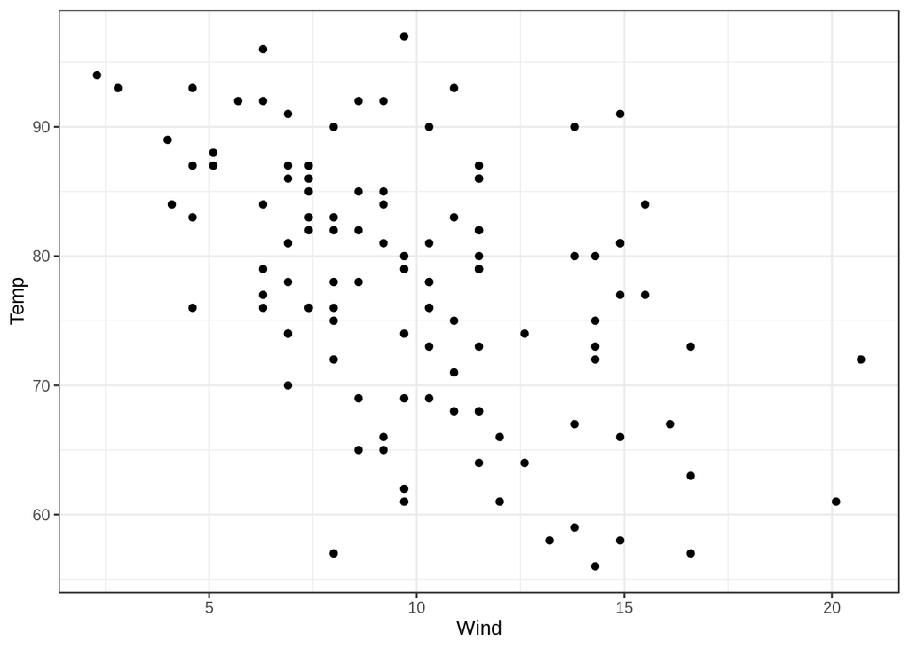

```r
 ggplot(data = train_regression) +
   geom_point(aes(x=Wind, y=Temp)) +
     theme_bw()
```

2. Create and fit a linear model to predict Temperature from Wind using the training set

```r
#help(train)

linear_regression <- train(Temp ~ Wind, data= train_regression, method = "lm")
```

3. Vizualize how your model performed on the train data by plotting the regression line on top of the train data points.

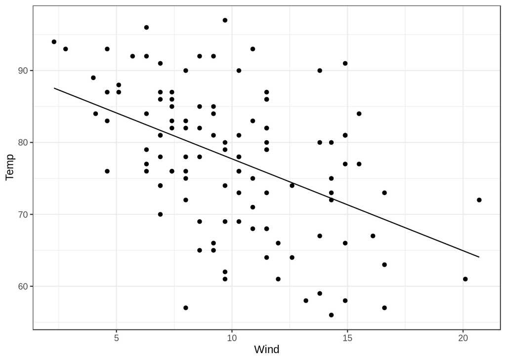

```r
 ggplot(data = train_regression) +
    geom_point(aes(x=Wind, y=Temp)) +
    geom_line(aes(x=Wind, y=predict(linear_regression, newdata = train_regression))) +
    theme_bw()
```

4. Explore how the model performs on the test data. For Linear Regression:
- The residuals should be close to zero.
- There should be equal variance around the regression line (homoscedasticity).
- Residuals should be normally distributed.
- Independent variables and residuals should not be correlated.

4 a) See how the model performs on the test data

```r
test_pred <- predict(linear_regression, newdata = test_regression)
```

4 b) Look at the residuals. Are they close to zero?

```r
median(resid(linear_regression))
```

```
## [1] 0.8357265
```

that is kind close to zero

4 c) Plot predicted temperature vs observed temperature. A strong model should show a strong correlation

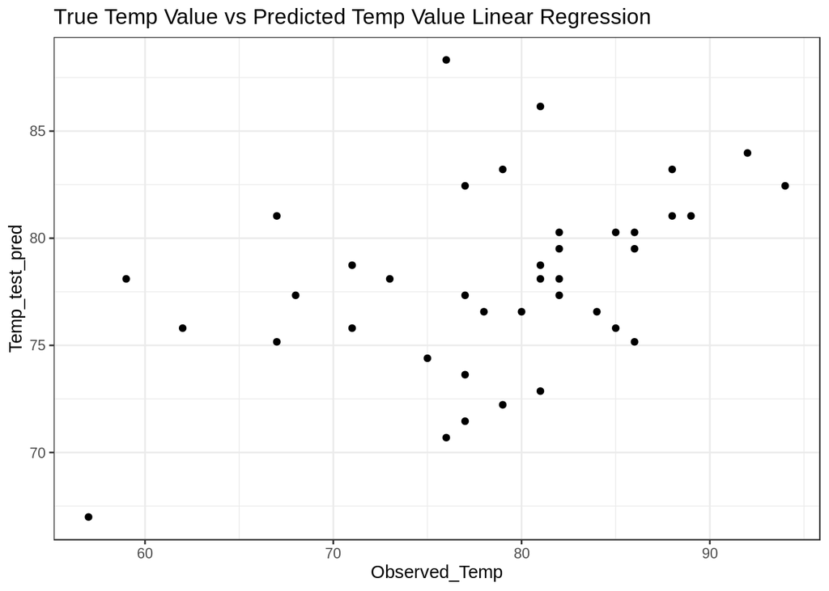

```r
test_pred <- predict(linear_regression, newdata = test_regression)

#plot the predicted values vs the observed values
plot_test_pred <- data.frame(Temp_test_pred = test_pred,
                                   Observed_Temp = test_regression$Temp)
ggplot(data = plot_test_pred) +
  geom_point(aes(x=Observed_Temp, y = Temp_test_pred)) +
  ggtitle("True Temp Value vs Predicted Temp Value Linear Regression") +
  theme_bw()
```

4 d) Visualize the predicted values in relation to the real data points. Look for homoscedasticity

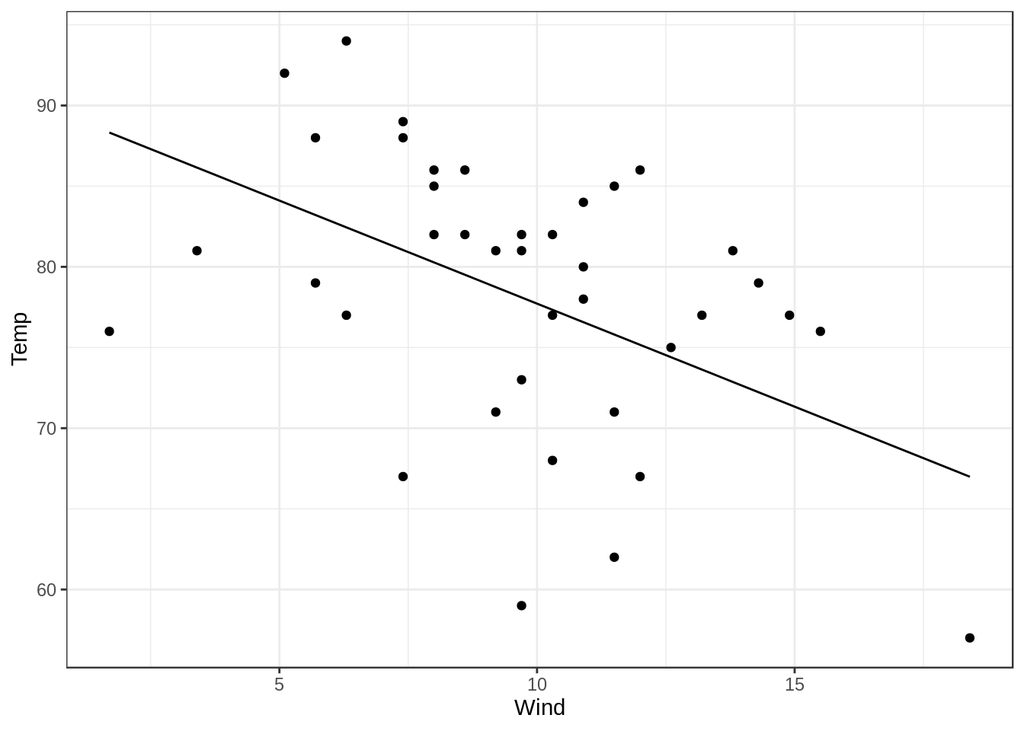

```r
# Extract coefficients from the model
coef = linear_regression$finalModel$coefficients
fun.1 = function(x) coef[1] - coef[2] *x
# plot the regression line on the predicted values
ggplot(data = test_regression) +
    geom_point(aes(x=Wind, y=Temp)) +
    geom_line(aes(x=Wind, y=predict(linear_regression, newdata = test_regression))) +
    theme_bw()
```

```r
# plot the original test values
```

4 e) Residuals should be normally distributed. Plot the density of the residuals

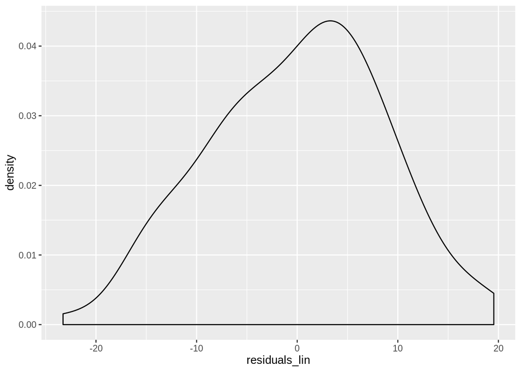

```r
residuals_lin <- residuals(linear_regression)

ggplot() +
  geom_density(aes(residuals_lin))
```

4 f) Independent variables and residuals should not be correlated

```r
cor.test(train_regression$Wind, resid(linear_regression))
```

```
##
##  Pearson's product-moment correlation
##
## data:  train_regression$Wind and resid(linear_regression)
## t = -1.5625e-15, df = 112, p-value = 1
## alternative hypothesis: true correlation is not equal to 0
## 95 percent confidence interval:
##  -0.1839148  0.1839148
## sample estimates:
##          cor
## -1.47641e-16
```

### Linear Regression with Regularization

```r
Lasso_regression <- train(Temp ~ Wind + Month, data = train_regression,method = 'lasso')
```

[figure not shown]

```r
test_pred <- predict(linear_regression, newdata = test_regression)

#plot the predicted values vs the observed values
plot_test_pred <- data.frame(Temp_test_pred = test_pred,
                                   Observed_Temp = test_regression$Temp)
ggplot(data = plot_test_pred) +
  geom_point(aes(x=Observed_Temp, y = Temp_test_pred)) +
  ggtitle("True Temp Value vs Predicted Temp Value Lasso Regression") +
  theme_bw()
```